# p8105_hw1_zf2352

Zhenkun Fang

2024-09-21

# Problem 1

## Clean and look at the dataset

```r
penguins = janitor::clean_names(penguins)
penguins
```

```
## # A tibble: 344 × 8
##    species island    bill_length_mm bill_depth_mm flipper_length_mm body_mass_g
##    <fct>   <fct>              <dbl>         <dbl>             <int>       <int>
##  1 Adelie  Torgersen           39.1          18.7               181        3750
##  2 Adelie  Torgersen           39.5          17.4               186        3800
##  3 Adelie  Torgersen           40.3          18                 195        3250
##  4 Adelie  Torgersen           NA            NA                  NA          NA
##  5 Adelie  Torgersen           36.7          19.3               193        3450
##  6 Adelie  Torgersen           39.3          20.6               190        3650
##  7 Adelie  Torgersen           38.9          17.8               181        3625
##  8 Adelie  Torgersen           39.2          19.6               195        4675
##  9 Adelie  Torgersen           34.1          18.1               193        3475
## 10 Adelie  Torgersen           42            20.2               190        4250
## # ℹ 334 more rows
## # ℹ 2 more variables: sex <fct>, year <int>
```

```r
nrow(penguins)
```

```
## [1] 344
```

```r
ncol(penguins)
```

```
## [1] 8
```

This data set contains various variables of penguins：

- ‘species’: the specie of each penguin (Adelie, Chinstrap, Gentoo).
- ‘island’: the island where each penguin comes from (Biscoe, Dream, Torgersen).
- ‘bill_length_mm’: the bill length of each penguin in millimeters.
- ‘bill_depth_mm’: the bill depth of each penguin in millimeter.
- ‘flipper_length_mm’: the flipper length of each penguin in millimeters.
- ‘body_mass_g’: the body mass of each penguin in grams.
- ‘sex’: the biological sex of each penguin.
- ‘year’: the year of birth of each penguin (2007, 2008, 2009).

There are 344 rows and 8 columns in this dataset.

```r
mean(penguins$flipper_length_mm, na.rm = TRUE)
```

```
## [1] 200.9152
```

The mean flipper length is 200.9152 mm.

## Scatterplot

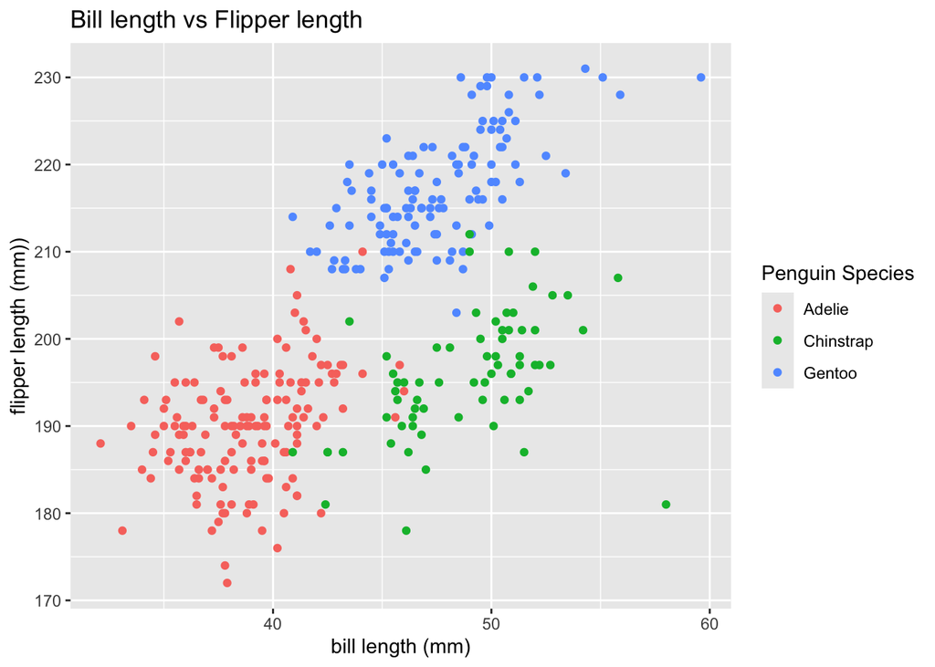

```r
ggplot(
  penguins,
  aes(x = bill_length_mm, y = flipper_length_mm, color = species)) +
  geom_point() +
  labs(
    title = "Bill length vs Flipper length",
    x = "bill length (mm)",
    y = "flipper length (mm))",
    color = "Penguin Species"
  )
```

```r
ggsave("scatterplot_flipper_vs_bill.png")
```

# Problem 2

## Create data frame

```r
set.seed(1235)

normal_sample = rnorm(10)

logical_vector = normal_sample > 0

character_vector = sample(letters, 10)

factor_vector <- factor(sample(c("Level1", "Level2", "Level3"), 10, replace = TRUE))

df <- data.frame(Random_Sample = normal_sample,
                 Greater_Than_Zero = logical_vector,
                 Character_Vector = character_vector,
                 Factor_Vector = factor_vector)

print(df)
```

```
##    Random_Sample Greater_Than_Zero Character_Vector Factor_Vector
## 1    -0.69798794             FALSE                l        Level3
## 2    -1.28485386             FALSE                m        Level2
## 3     0.98995901              TRUE                d        Level1
## 4     0.11177583              TRUE                b        Level3
## 5     0.11420767              TRUE                o        Level1
## 6     1.69819652              TRUE                n        Level3
## 7     0.04784562              TRUE                g        Level2
## 8     0.65486241              TRUE                i        Level2
## 9     1.36528367              TRUE                e        Level1
## 10    0.40257296              TRUE                h        Level1
```

## Calculate mean

```r
dbl_mean = mean(pull(df, Random_Sample)) %>%
  print()
```

```
## [1] 0.3401862
```

```r
lgl_mean = mean(pull(df, Greater_Than_Zero)) %>%
  print()
```

```
## [1] 0.8
```

```r
chr_mean = mean(pull(df, Character_Vector)) %>%
  print()
```

```
## [1] NA
```

```r
fct_mean = mean(pull, Factor_Vector) %>%
  print()
```

```
## [1] NA
```

R can calculate the mean of random sample and logical vector (double and logical vectors).

```r
lgl_mean1 = mean(as.numeric(pull(df, Greater_Than_Zero))) %>%
  print()

chr_mean1 = mean(as.numeric(pull(df, Character_Vector))) %>%
  print()

fct_mean1 = mean(as.numeric(pull(df, Factor_Vector))) %>%
  print()
```

[output not shown]

R can calculate the mean of logical vector and factor vector. However, the mean of character vector cannot be calculated.

logical vector: When converting a logical vector to numeric, TRUE becomes 1 and FALSE becomes 0.

character vector: When converting a character vector to numeric, R returns NA (missing values) because character data cannot be directly translated into numbers.

factor vector: When converting a factor to numeric, the factor levels are converted into integers representing their internal codes.

This helps explain what happens when I try to take the mean.